# Statistics in Python: Passing-Bablok Regression

⇦ Back

This type of regression analysis was first published in Passing & Bablok (1983)<sup>1</sup>. As the [Wikipedia article](https://en.wikipedia.org/wiki/Passing%E2%80%93Bablok_regression) states:

> Passing–Bablok regression is a statistical method for non-parametric regression analysis suitable for method comparison studies.

Essentially, when two different methods are being used to take the same measurement a line-of-best-fit can fitted to the points. The Passing-Bablok method does this by:

- Drawing a line between each pair of points in turn
- Taking the gradient of each of these lines
- Extending these lines to the y-axis and taking the y-intercepts
- Taking the median of the gradients and the median of the y-intercepts of these lines

The median gradient and median y-intercept create the line-of-best-fit. It has an associated confidence interval which can be interpreted as follows:

- If 1 is within the confidence interval of the gradient and 0 within the confidence interval of the y-intercept, then the two methods are comparable within the investigated concentration range
- If 1 is not in the confidence interval of the gradient then there is a proportional difference between the two methods
- If 0 is not in the confidence interval of the y-interval then there is a systematic difference

Let’s use the following hypothetical example which comes from Giavarina (2015)<sup>2</sup>. Imagine that a set of objects were each measured twice - once using ‘Method A’ and once using ‘Method B’ - giving the two lists of measurements below:

```python
import pandas as pd

df = pd.DataFrame({
    'Method A': [
        1.0, 5.0, 10.0, 20.0, 50.0, 40.0, 50.0, 60.0, 70.0, 80.0, 90.0, 100.0,
        150.0, 200.0, 250.0, 300.0, 350.0, 400.0, 450.0, 500.0, 550.0, 600.0,
        650.0, 700.0, 750.0, 800.0, 850.0, 900.0, 950.0, 1000.0
    ],
    'Method B': [
        8.0, 16.0, 30.0, 24.0, 39.0, 54.0, 40.0, 68.0, 72.0, 62.0, 122.0, 80.0,
        181.0, 259.0, 275.0, 380.0, 320.0, 434.0, 479.0, 587.0, 626.0, 648.0,
        738.0, 766.0, 793.0, 851.0, 871.0, 957.0, 1001.0, 960.0
    ]
})
```

First, let’s visualise this data:

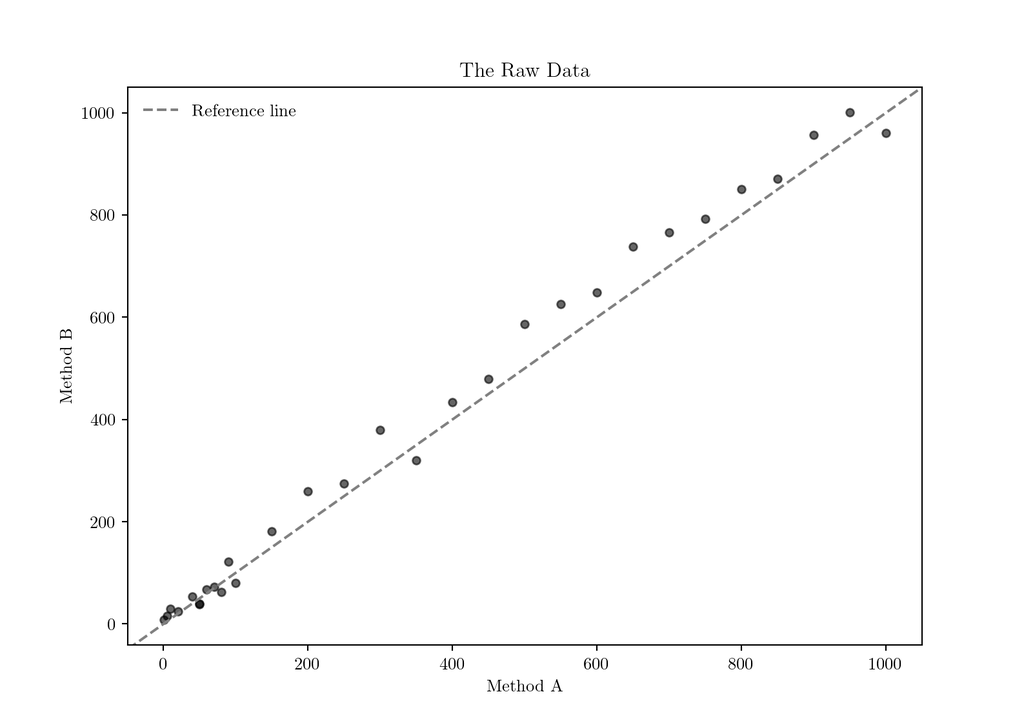

```python
import matplotlib.pyplot as plt

# Options
x = 5  # Want figures to be A5
plt.rc('figure', figsize=[46.82 * .5**(.5 * x), 33.11 * .5**(.5 * x)])
plt.rc('text', usetex=True)
plt.rc('font', family='serif')
plt.rc('text.latex', preamble=r'\usepackage{textgreek}')

ax = plt.axes()
ax.set(
    title='The Raw Data',
    xlabel='Method A',
    ylabel='Method B'
)
# Scatter plot
ax.scatter(df['Method A'], df['Method B'], c='k', s=20, alpha=0.6, marker='o')
# Get axis limits
left, right = plt.xlim()
top, bottom = plt.ylim()
# Keep current axis limits
ax.set_xlim(left, right)
ax.set_ylim(top, bottom)
# Reference line
ax.plot(
    [left, right], [left, right], c='grey', ls='--', label='Reference line'
)
# Legend
ax.legend(frameon=False)
# Show
plt.show()
```

Next, take each pair of points on this scatter plot and calculate the gradient of the straight line that connects them:

```python
#
# Calculate the gradients of the lines between each pair of points
#
method1 = df['Method A']
method2 = df['Method B']
n_points = len(method1)
# sv is a list of the gradients between of each pair of points
sv = []
# k is the number of gradients less than -1
k = 0
for i in range(n_points - 1):
    for j in range(i + 1, n_points):
        dy = method2[j] - method2[i]
        dx = method1[j] - method1[i]
        # Ignore gradients that are vertical (ie the x values of the points
        # are the same)
        if dx != 0:
            gradient = dy / dx
        elif dy < 0:
            gradient = -1.e+23
        elif dy > 0:
            gradient = 1.e+23
        else:
            gradient = None
        if gradient is not None:
            sv.append(gradient)
            k += (gradient < -1)
# Sort the gradients into ascending order
sv.sort()
```

Find the estimated gradient of the line-of-best-fit from the list of all between-point gradients and calculate the confidence interval of this value:

```python
import math

#
# Find the estimated gradient and confidence limits
#
m0 = (len(sv) - 1) / 2
if m0 == int(m0):
    # If odd
    gradient_est = sv[k + int(m0)]
else:
    # If even
    gradient_est = 0.5 * (sv[k + int(m0 - 0.5)] + sv[k + int(m0 + 0.5)])
# Calculate the index of the upper and lower confidence bounds
w = 1.96
ci = w * math.sqrt((n_points * (n_points - 1) * (2 * n_points + 5)) / 18)
n_gradients = len(sv)
m1 = int(round((n_gradients - ci) / 2))
m2 = n_gradients - m1 - 1
# Calculate the lower and upper bounds of the gradient
(gradient_lb, gradient_ub) = (sv[k + m1], sv[k + m2])
```

Finally, get the estimated y-intercept of the line-of-best-fit from the list of all y-intercepts:

```python
import numpy as np


def calc_intercept(method1, method2, gradient):
    """Calculate intercept given points and a gradient."""
    temp = []
    for i in range(len(method1)):
        temp.append(method2[i] - gradient * method1[i])
    return np.median(temp)


# Calculate the intercept as the median of all the intercepts of all the
# lines connecting each pair of points
int_est = calc_intercept(method1, method2, gradient_est)
int_ub = calc_intercept(method1, method2, gradient_lb)
int_lb = calc_intercept(method1, method2, gradient_ub)
```

This yields a result:

```python
print(f'Gradient = {gradient_est:4.2f} ({gradient_ub:4.2f} - {gradient_lb:4.2f})')
print(f'Y-intercept = {int_est:4.2f} ({int_ub:4.2f} - {int_lb:4.2f})')
```

```
## Gradient = 1.06 (1.09 - 1.02)
```

[output not shown]

We can again visualise this, with the line-of-best-fit and its confidence interval added in:

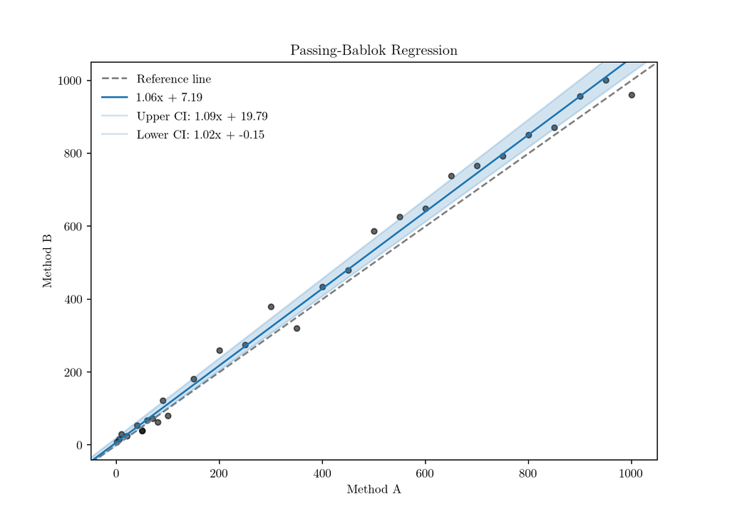

```python
#
# Plot
#
ax = plt.axes()
ax.set(
    title='Passing-Bablok Regression',
    xlabel='Method A',
    ylabel='Method B'
)
# Scatter plot
ax.scatter(df['Method A'], df['Method B'], c='k', s=20, alpha=0.6, marker='o')
# Get axis limits
left, right = plt.xlim()
top, bottom = plt.ylim()
# Keep current axis limits
ax.set_xlim(left, right)
ax.set_ylim(top, bottom)
# Reference line
ax.plot(
    [left, right], [left, right], c='grey', ls='--', label='Reference line'
)
# Passing-Bablok regression line
x = np.array([left, right])
y = gradient_est * x + int_est
ax.plot(x, y, label=f'{gradient_est:4.2f}x + {int_est:4.2f}')
# Passing-Bablok regression line - confidence intervals
x = np.array([left, right])
y_lb = gradient_lb * x + int_lb
y_ub = gradient_ub * x + int_ub
ax.plot(
    x, y_ub, c='tab:blue', alpha=0.2,
    label=f'Upper CI: {gradient_ub:4.2f}x + {int_ub:4.2f}'
)
ax.plot(
    x, y_lb, c='tab:blue', alpha=0.2,
    label=f'Lower CI: {gradient_lb:4.2f}x + {int_lb:4.2f}'
)
ax.fill_between(x, y_ub, y_lb, alpha=0.2)
# Legend
ax.legend(frameon=False)
# Show
plt.show()
```

If we are doing multiple Passing-Bablok analyses it will be more convenient in the long run to create a function for it. This looks like this:

```python
def passing_bablok(method1, method2):
    """Perform Passing-Bablok analysis."""
    #
    # Calculate the gradients of the lines between each pair of points
    #
    n_points = len(method1)
    # sv is a list of the gradients between of each pair of points
    sv = []
    # k is the number of gradients less than -1
    k = 0
    for i in range(n_points - 1):
        for j in range(i + 1, n_points):
            dy = method2[j] - method2[i]
            dx = method1[j] - method1[i]
            # Ignore gradients that are vertical (ie the x values of the points
            # are the same)
            if dx != 0:
                gradient = dy / dx
            elif dy < 0:
                gradient = -1.e+23
            elif dy > 0:
                gradient = 1.e+23
            else:
                gradient = None
            if gradient is not None:
                sv.append(gradient)
                k += (gradient < -1)
    # Sort the gradients into ascending order
    sv.sort()

    #
    # Find the estimated gradient and confidence limits
    #
    m0 = (len(sv) - 1) / 2
    if m0 == int(m0):
        # If odd
        gradient_est = sv[k + int(m0)]
    else:
        # If even
        gradient_est = 0.5 * (sv[k + int(m0 - 0.5)] + sv[k + int(m0 + 0.5)])
    # Calculate the index of the upper and lower confidence bounds
    w = 1.96
    ci = w * math.sqrt((n_points * (n_points - 1) * (2 * n_points + 5)) / 18)
    n_gradients = len(sv)
    m1 = int(round((n_gradients - ci) / 2))
    m2 = n_gradients - m1 - 1
    # Calculate the lower and upper bounds of the gradient
    (gradient_lb, gradient_ub) = (sv[k + m1], sv[k + m2])

    def calc_intercept(method1, method2, gradient):
        """Calculate intercept given points and a gradient."""
        temp = []
        for i in range(len(method1)):
            temp.append(method2[i] - gradient * method1[i])
        return np.median(temp)

    # Calculate the intercept as the median of all the intercepts of all the
    # lines connecting each pair of points
    int_est = calc_intercept(method1, method2, gradient_est)
    int_ub = calc_intercept(method1, method2, gradient_lb)
    int_lb = calc_intercept(method1, method2, gradient_ub)

    return (gradient_est, gradient_lb, gradient_ub), (int_est, int_lb, int_ub)
```

Here it is all put together:

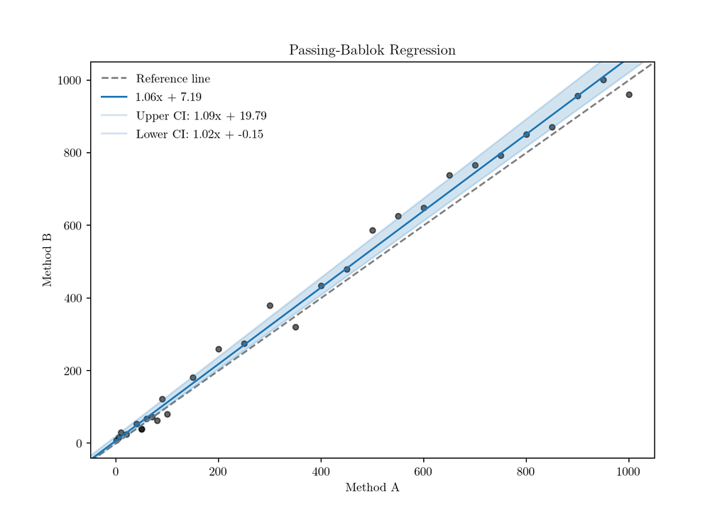

```python
df = pd.DataFrame({
    'Method A': [
        1.0, 5.0, 10.0, 20.0, 50.0, 40.0, 50.0, 60.0, 70.0, 80.0, 90.0, 100.0,
        150.0, 200.0, 250.0, 300.0, 350.0, 400.0, 450.0, 500.0, 550.0, 600.0,
        650.0, 700.0, 750.0, 800.0, 850.0, 900.0, 950.0, 1000.0
    ],
    'Method B': [
        8.0, 16.0, 30.0, 24.0, 39.0, 54.0, 40.0, 68.0, 72.0, 62.0, 122.0, 80.0,
        181.0, 259.0, 275.0, 380.0, 320.0, 434.0, 479.0, 587.0, 626.0, 648.0,
        738.0, 766.0, 793.0, 851.0, 871.0, 957.0, 1001.0, 960.0
    ]
})

beta, alpha = passing_bablok(df['Method A'], df['Method B'])

#
# Plot
#
ax = plt.axes()
ax.set(
    title='Passing-Bablok Regression',
    xlabel='Method A',
    ylabel='Method B'
)
# Scatter plot
ax.scatter(df['Method A'], df['Method B'], c='k', s=20, alpha=0.6, marker='o')
# Get axis limits
left, right = plt.xlim()
top, bottom = plt.ylim()
# Keep current axis limits
ax.set_xlim(left, right)
ax.set_ylim(top, bottom)
# Reference line
ax.plot(
    [left, right], [left, right], c='grey', ls='--', label='Reference line'
)
# Passing-Bablok regression line
x = np.array([left, right])
y = beta[0] * x + alpha[0]
ax.plot(x, y, label=f'{beta[0]:4.2f}x + {alpha[0]:4.2f}')
# Passing-Bablok regression line - confidence intervals
x = np.array([left, right])
y_lb = beta[1] * x + alpha[1]
y_ub = beta[2] * x + alpha[2]
ax.plot(
    x, y_ub, c='tab:blue', alpha=0.2,
    label=f'Upper CI: {beta[2]:4.2f}x + {alpha[2]:4.2f}'
)
ax.plot(
    x, y_lb, c='tab:blue', alpha=0.2,
    label=f'Lower CI: {beta[1]:4.2f}x + {alpha[1]:4.2f}'
)
ax.fill_between(x, y_ub, y_lb, alpha=0.2)
# Legend
ax.legend(frameon=False)
# Show
plt.show()
```

# References

<sup>1</sup>Passing H, Bablok W (1983). “A new biometrical procedure for testing the equality of measurements from two different analytical methods. Application of linear regression procedures for method comparison studies in Clinical Chemistry, Part I”. *Journal of Clinical Chemistry and Clinical Biochemistry*. **21** (11): 709–20. doi: [10.1515/cclm.1983.21.11.709](https://doi.org/10.1515%2Fcclm.1983.21.11.709). PMID: [6655447](https://pubmed.ncbi.nlm.nih.gov/6655447/)  
<sup>2</sup>Giavarina D (2015). “Understanding Bland Altman analysis”. *Biochemia Medica*. **25** (2):141-151. doi: [10.11613/BM.2015.015](https://www.ncbi.nlm.nih.gov/pmc/articles/PMC4470095/pdf/bm-25-141.pdf).

⇦ Back